# Guided Project: Exploring NYC Schools Survey Data

John Chapman

July 10, 2019

In this project, I will analize data from the New York City school depormant to understand whether parent, teacher, and student perceptions of the following factors affect average school SAT scores (an indicator of academic performanece):

1. Safety
2. Engagement
3. Communication
4. Academics

The data, collected in 2011, are publicly available and can be accessed here.

I’ll start by loading the packages that I’ll need for this analysis:

```r
library(readr)
library(dplyr)
library(stringr)
library(purrr)
library(tidyr)
```

[output not shown]

load data file downloaded from https://data.cityofnewyork.us/Education/2011-NYC-School-Survey/mnz3-dyi8

```r
combined <- read_csv("data/combined.csv")
```

```r
master1 <- masterfile %>%
  select(dbn, saf_p_11:com_s_11)
```

[output not shown]

```r
combined <- combined %>%
  rename(DBN = dbn)
```

[output not shown]

Create a correlation matrix to look for interesting relationships between pairs of variables in `combined_survey` and convert it to a tibble so it’s easier to work with using tidyverse tools.

```r
cor_mat <- survey_combined %>%    ## interesting relationshipsS
  select(avg_sat_score, saf_p_11:aca_tot_11) %>%
  cor(use = "pairwise.complete.obs")
cor_tib <- cor_mat %>%
  as_tibble(rownames = "variable")
```

Look for correlations of other variables with `avg_sat_score` that are greater than 0.25 or less than -0.25 (strong correlations).

```r
strong_cors <- cor_tib %>%
  select(variable, avg_sat_score) %>%
  filter(avg_sat_score > 0.25 | avg_sat_score < -0.25)
```

Make scatter plots of those variables with `avg_sat_score` to examine relationships more closely.

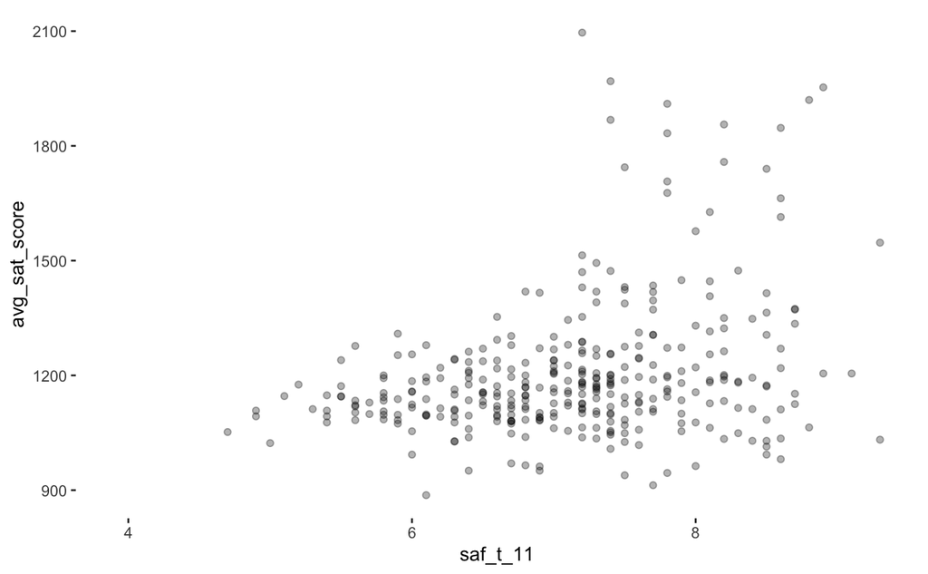

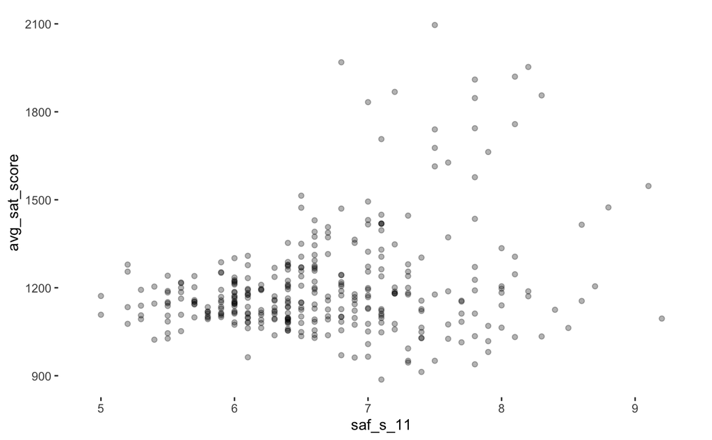

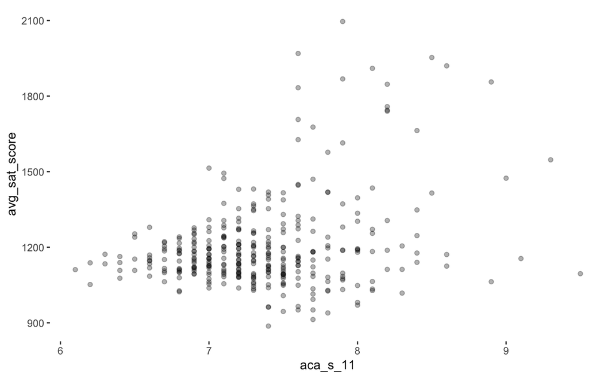

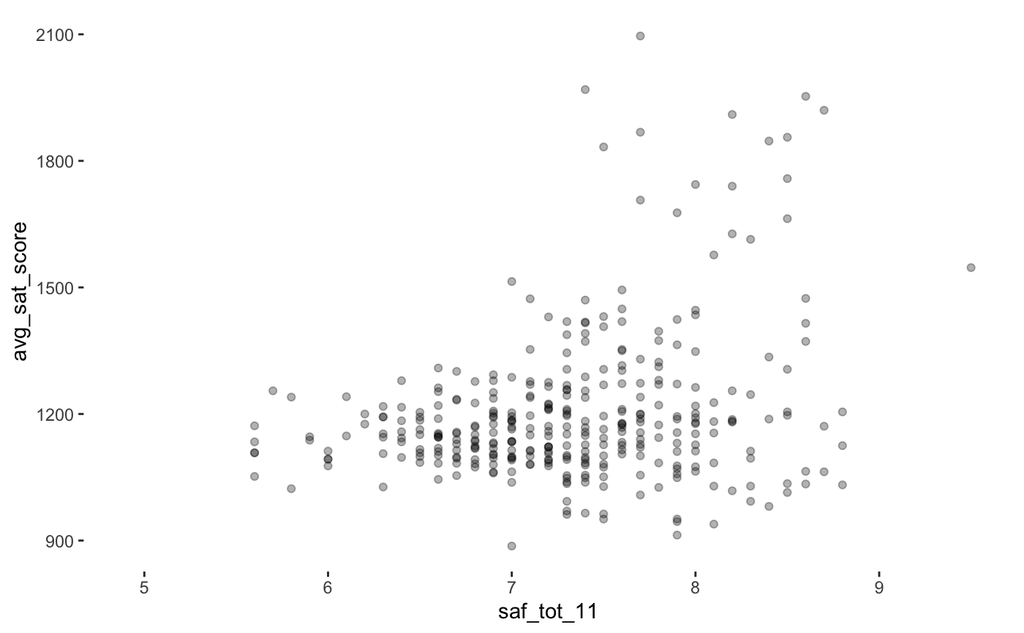

```r
map2(x_var, y_var, create_scatter)
```

Reshape the data so that you can investigate differences in student, parent, and teacher responses to survey questions.

```r
combined_survey_gather <- combined_survey_gather %>%
  mutate(response_type = ifelse(response_type  == "_p_", "parent",
                                ifelse(response_type == "_t_", "teacher",
                                       ifelse(response_type == "_s_", "student",
                                              ifelse(response_type == "_to", "total", "NA")))))
```

[output not shown]

Make a boxplot to see if there appear to be differences in how the three groups of responders (parents, students, and teachers) answered the four questions.

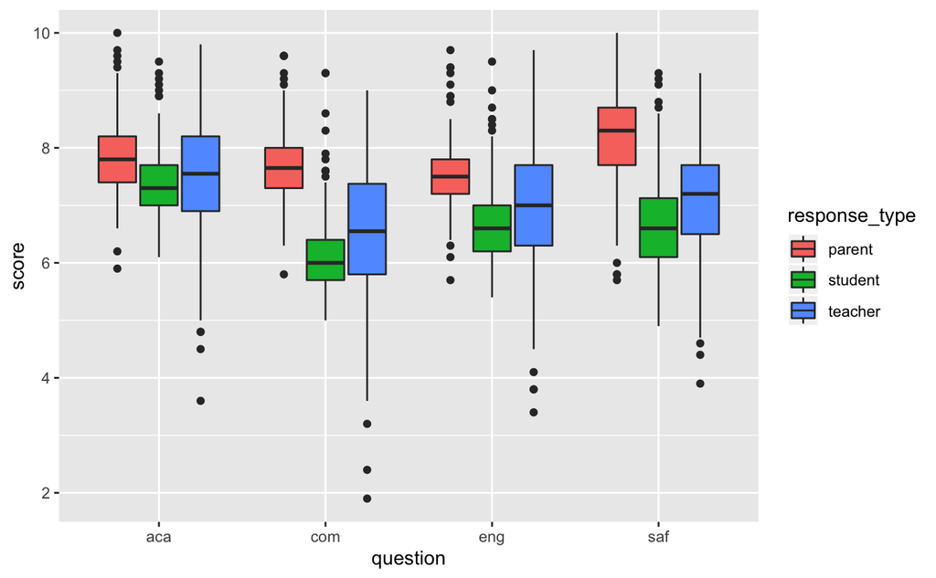